# Differential gene expression (DGE) analysis

Anna Rybina

## 0. Prerequisites: installation and import of libraries

The current work requires the following packages (R version: 3.6.3):

```r
require('ggplot2')
require('DESeq2')
require('enrichplot')
require('dplyr')
require('clusterProfiler')
require('DOSE')
require('cowplot')
require('tidyr')
require('reshape2')
require('ggpubr')
require('pheatmap')
require('ggrepel')
require('org.EcK12.eg.db')
require('latex2exp')
require('Polychrome')
require('stringr')
require('RColorBrewer')
require('glue')
require("purrr")
```

## 1. Specify functions and some variables for downstream steps

#### 1. Custom pallette for COG categories

Assign a certain color to each COG category using customizes glasbey pallette

```r
P36 <- palette36.colors(36)
names(P36) <- c(1:length(P36))
P27 <- P36[-c(3,22,23,36, 32,14, 34, 35, 33)]

all_COG_categories <- c('E'="Amino acid transport and metabolism [E]",
                        "G"="Carbohydrate transport and metabolism [G]",
                        "D"="Cell cycle control, cell division, chromosome partitioning [D]",
                        "N"="Cell Motility [N]",
                        'M'="Cell wall/membrane/envelope biogenesis [M]",
                        'B'="Chromatin structure and dynamics [B]",
                        'H'="Coenzyme transport and metabolism [H]" ,
                        'Z'="Cytoskeleton [Z]",
                        'V'="Defense mechanisms [V]",
                        'C'="Energy production and conversion [C]",
                        'W'="Extracellular structures [W]",
                        'S'="Function unknown [S]",
                        'R'="General function prediction only [R]",
                        'P'="Inorganic ion transport and metabolism [P]",
                        'U'="Intracellular trafficking, secretion, and vesicular transport [U]",
                        'I'="Lipid transport and metabolism [I]",
                        'X'="Mobilome: prophages, transposons [X]",
                        'Y'="Nuclear structure [Y]",
                        'F'="Nucleotide transport and metabolism [F]",
                        'O'="Posttranslational modification, protein turnover, chaperones [O]",
                        'A'="RNA processing and modification [A]",
                        'L'="Replication, recombination and repair [L]",
                        'Q'="Secondary metabolites biosynthesis, transport and catabolism [Q]",
                        'T'="Signal transduction mechanisms [T]",
                        'K'="Transcription [K]",
                        "J"="Translation, ribosomal structure and biogenesis [J]")

names(P27) <- append(unname(unlist(all_COG_categories)), c('Not defined'))
```

Check resulting palette:

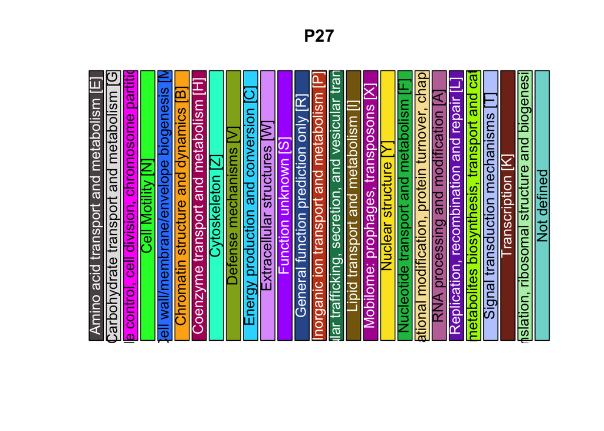

```r
swatch(P27)
```

#### 2. Combine feature counts output with the gff annotation data:

```r
combine_featureCount_GFF_data<- function(featureCounts_file, gff_file){
   # Import feature counts data

    message('Importing feature counts data')
    featureCounts_data <- read.csv(featureCounts_file,
                                   sep="\t",
                                   #row.names='Geneid',
                                   comment.char = "#")

    # Rename Geneid column to locus_tag column
    featureCounts_data <- dplyr::rename(featureCounts_data, locus_tag = Geneid)

    # Import GFF annotation file
    message('Importing GFF annotation file ')
    gff <- read.csv(gff_file, sep="\t", comment.char = "#", header=F)

    # Set column names
    colnames(gff) <- paste0('V', c(1:9))

    # Extract product names, locus_tags, and IDs
    # from the last column in annotation
    # remove exon rows to avoid duplication in data
    message('Getting product names and IDs from the GFF annotation')
    gff <- gff %>%
      filter(str_detect(V9, "product=") &
               str_detect(V9, "locus_tag=") &
               (!str_detect(V3, "exon"))) %>%
      mutate(product = str_split_fixed(V9, "product=", 2)[,2] %>%
               gsub( ';.+$', '', .) %>%
               gsub( '%2C', ',', .) %>%
               gsub( '%3B', ';', .),
             locus_tag = str_split_fixed(V9, "locus_tag=", 2)[,2] %>%
               gsub( ';.+$', '', .),
             ID=str_split_fixed(V9, "ID=", 2)[,2] %>%
               gsub( ';.+$', '', .))

    # merge feature counts and gff data by locus_tag column
    message('Merging feature counts and annotation data')
    featureCounts_gff <- merge(featureCounts_data,
                               gff[!duplicated(gff$locus_tag),],
                               by = "locus_tag",
                               all = T)

    # select  columns from the feature counts part,
    # product and ID columns from the GFF part
    featureCounts_gff<- featureCounts_gff %>% dplyr::select(c(1:14,24,25))

    # replace missing values in gene with ID

    featureCounts_gff %>% mutate(., gene = ifelse(!is.na(gene), gene, 'ID'))

    # replace misssing product name with pseudogene
    featureCounts_gff <- featureCounts_gff %>%
      mutate(product=ifelse(is.na(product) | product=='' | product=='NA',
                            'pseudogene', product))

    # remove duplicated rows
    featureCounts_gff <- featureCounts_gff[!duplicated(featureCounts_gff), ]

    # make locus_tag as row names
    row.names(featureCounts_gff) <- featureCounts_gff$locus_tag
    message('Done')
    return(featureCounts_gff)
}
```

#### 3. Construct the DESeqDataSet object

Construct the DESeqDataSet object based on count matrix, add gene/ID and product names as metadata, and filter out rows which count sum is less than 10:

```r
construct_DESeqDataSet <- function(featureCounts_gff){
    ## Create a count matrix
    message('Creating count matrix')
    # select only columns containing counts
    counts_df <- featureCounts_gff[str_detect(colnames(featureCounts_gff),
                                              '.bam')]
    # Get condition and replicate info from names of SAM files
    # used as input for feature counts
    colnames(counts_df) <- as.vector(sapply(strsplit(colnames(counts_df),'_'),
                                            "[", 6 ))
    counts_mtx <- as.matrix(counts_df)

    ## Create The DESeqDataSet object from count matrix
    message('Constructing the DESeqDataSet object')
    # construct data frame on conditions
    # rows of colData should correspond to columns of countData
    coldata<-data.frame(row.names=colnames(counts_mtx),
                        condition=factor(gsub('.{1}$', '',
                                              colnames(counts_df))))
    dds <- DESeqDataSetFromMatrix(countData = counts_mtx,
                                  colData = coldata,
                                  design = ~ condition)

    ## Add metadata to DESeqDataSet
    message('Adding metadata (gene/ID and product names) to DESeqDataSet')
    featureData <- data.frame(geneID_product=paste(featureCounts_gff$gene,
                                                   featureCounts_gff$product,
                                                   sep=', '),
                              product=featureCounts_gff$product,
                              geneID = featureCounts_gff$gene,
                              locus_tag=featureCounts_gff$locus_tag)
    mcols(dds) <- DataFrame(mcols(dds), featureData)

    ## Pre-filter
    message('Filtering low count data')
    keep <- rowSums(counts(dds)) >= 10
    dds <- dds[keep,]

    message('Done')
    return(dds)
}
```

#### 4. Calculate differential expression analysis

Calculate standard differential expression analysis using glucose as a baseline condition:

```r
compute_DESeq <- function(DESeqDataSet, sugar_control='gluc'){
    # factor level
    message(glue("Relevel factors in DESeqDataSet using {sugar_control} as a baseline"))
    DESeqDataSet$condition <- relevel(DESeqDataSet$condition,
                                      ref = sugar_control)

    # standard differential expression analysis
    message('Starting differential expression analysis')
    dds <- DESeq(DESeqDataSet)
    message('Done!')
    return(dds)
}
```

#### 5. Get DESeq results

Get DESeq results (hypothesis testing via the Wald test, add metadata, and reorder results according to log2FoldChange):

```r
get_DESeq_results <- function(dds,
                              sugar_to_compare,
                              sugar_control='gluc',
                              alpha_threshold=0.05){
    # Indicate two groups we want to compare
    # Hypothesis testing via the Wald test
    message(glue('Specifying contrasts: compare {sugar_to_compare} conditions to a baseline {sugar_control}'))
    contrast <- c("condition", sugar_to_compare, sugar_control)
    message('Hypothesis testing via the Wald test')
    res <- results(dds, contrast = contrast, alpha = alpha_threshold)

    # Add columns containing gene names
    message('Adding geneID, locus_tag, and product names to results')
    res[c('product','geneID','locus_tag')] <- mcols(dds)[row.names(res), c('product','geneID','locus_tag')]

    # Reorder according to log2FoldChange
    message('Reordering based on log2FoldChange')
    resOrdered <- res[order(res$log2FoldChange),]

    # Return list of results
    message('Done!')
    return(resOrdered)
}
```

#### 6. Make volcano plots

Plot volcano plots (log p-value adjusted vs log2FoldChange ), using cutoff values for Log2FoldChange and adjusted p-value. Add geneID for top 20 genes

```r
plot_volcano <- function(resSig,
                         l2fc_cutoff=2,
                         padj_cutoff=0.05,
                         top_number=20){
    options(ggrepel.max.overlaps = Inf)
    de <- as.data.frame(resSig)
    # Add a column to the data frame to specify if they are UP- or DOWN- regulated (log2FoldChange respectively positive or negative)
    # add a column of NAs
    de$diffexpressed <- "NO"
    # if log2Foldchange > l2fc_cutoff and padj < padj_cutoff, set as "UP"
    de$diffexpressed[de$log2FoldChange > l2fc_cutoff & de$padj < padj_cutoff] <- "UP"
    # if log2Foldchange < -l2fc_cutoff and padj < padj_cutoff, set as "DOWN"
    de$diffexpressed[de$log2FoldChange < -l2fc_cutoff & de$padj < padj_cutoff] <- "DOWN"

    # Create a new column "delabel" to de, that will contain the name of genes differentially expressed (NA in case they are not)
    de$delabel <- NA
    top_de <- subset(de[c(1:top_number, (dim(de)[1]-top_number):dim(de)[1]), ], diffexpressed !='NO')
    top_select <- row.names(top_de)
    #de[top_select, 'delabel'] <- de[top_select, 'geneID']
    de[top_select,]$delabel <- as.vector(de[top_select,]$geneID)

    x_pos <- round(abs(max(de$log2FoldChange)) + 2)
    x_neg <- round(abs(min(de$log2FoldChange)) + 2)

    # Re-plot, color the points with "diffexpressed"
    p <- ggplot(data=de, aes(x=log2FoldChange,
                             y=-log10(padj),
                             col=diffexpressed,
                             label=delabel)) +
      geom_point(alpha = 0.4) +
      theme_minimal() +
      geom_vline(xintercept=c(-l2fc_cutoff, l2fc_cutoff), col="#CF9FFF") +
      geom_hline(yintercept=-log10(padj_cutoff), col="#CF9FFF") +
      scale_color_manual(values=c("#008080", "grey", "#E30B5C")) +
      #xlab(TeX("log_{2}(fold change)")) +
      xlab(expression(log[2]('fold change'))) +
      #ylab(TeX("log_{10}(adjusted p-value)")) +
      ylab(expression(log[10]('adjusted p-value'))) +
      geom_text_repel(size = 5, box.padding = unit(0.35, "lines"),
                      point.padding = unit(0.3, "lines")) +
      labs(color = "Differentially expressed \ngenes") +
      xlim(c(-x_neg, x_pos))
    return(p)
}
```

#### 7. Prepare annotation data for heatmaps based on COG categoris from EggNog

Assign COG categories to features using EggNog annotation and construct row data for annotating counts heatmap of top vsd genes:

```r
make_annotaton_row_data_eggnog <- function(mcols_data,
                                           eggnog_file_path,
                                           all_COG_categories){
  # Read csv EggNog annotation file
  eggnog_mapper <- read.csv(eggnog_file_path,
                            sep='\t',
                            comment.char = "#",
                            header=F)
  # Select query (locus_tag) and COG_category columns,
  # rename query column to locus_tag
  eggnog_mapper <- eggnog_mapper %>%
      dplyr::select(c(V1, V7)) %>%
      dplyr::rename(locus_tag=V1)
  ## Construct dataframe for row annotation:
  # add COG_category  columns by merging with mcols_data
  # select the first COG category letter if several were predicted
  # map COG category letter to its full description
  # if COG category is absent, put 'Not defined'
  # specify locus_tag, geneID, product as description of the feature in one line
  # select only description of the feature and COG category columns
  # rename COG category column
  annotation_data_row <- merge(mcols_data, eggnog_mapper, all.x=T) %>%
      as.data.frame(.)  %>%
      mutate(V7=substr(V7, start = 1, stop = 1)) %>%
      mutate(V7=as.character(all_COG_categories[match(V7,
                                                      names(all_COG_categories))
                                                ])) %>%
      mutate(V7=ifelse(is.na(V7) | V7=='' | V7=='-', 'Not defined', V7)) %>%
      mutate(locus_tag_geneID_product = paste0(locus_tag,
                                               ', ',
                                               geneID_product )) %>%
      dplyr::select(c(locus_tag_geneID_product, V7))  %>%
      dplyr::rename('COG category' = V7)

    order_geneID_product <- annotation_data_row[order(annotation_data_row['COG category']),'locus_tag_geneID_product']
    row.names(annotation_data_row) <- annotation_data_row$locus_tag_geneID_product
    annotation_data_row <- annotation_data_row[order_geneID_product,]
    annotation_data_row <- annotation_data_row[-1]
    return(annotation_data_row)
}
```

#### 8. Plot heatmap and save it as a pdf file

```r
create_pheatmap <- function(matrix,
                            annotation_data_row,
                            annotation_data_col,
                            custom_annot_colors,
                            fontsize_row_=2,
                            fontsize_=8,
                            down_color='#008080',
                            up_color="#E30B5C"){
    nHalf <- 50
    Min <- round(min(matrix), 3)
    Max <- round(max(matrix), 3)
    Thresh <- 0
    ## Make vector of colors for values below threshold
    rc1 <- colorRampPalette(colors = c(down_color, "white"), space="Lab")(nHalf)
    ## Make vector of colors for values above threshold
    rc2 <- colorRampPalette(colors = c("white", up_color), space="Lab")(nHalf)
    rampcols <- c(rc1, rc2)
    ## Set the color for values between 49 and 51.
    rampcols[c(nHalf, nHalf+1)] <- rgb(t(col2rgb("white")), maxColorValue=256)

    rb1 <- seq(Min, Thresh, length.out=nHalf+1)
    rb2 <- seq(Thresh, Max, length.out=nHalf+1)[-1]
    rampbreaks <- c(rb1, rb2)

    p <-pheatmap(matrix[rownames(annotation_data_row),],
             annotation_row=annotation_data_row,
             annotation_col=annotation_data_col,
             annotation_colors = custom_annot_colors,
             show_rownames=T,
             color=rampcols,
             breaks=rampbreaks,
             cluster_cols=F,
             cluster_rows=F,
             border_color=FALSE,
             show_colnames=T,
             annotation_names_row = FALSE,
             fontsize_row = fontsize_row_,
             fontsize = fontsize_,
             angle_col = "45")
    return(p)
 }
```

Save pheatmap as a pdf file:

```r
save_pheatmap_pdf <- function(x, setwd_dir, filename, width=10, height=9){
    setwd(setwd_dir)
    stopifnot(!missing(x))
    stopifnot(!missing(filename))
    pdf(filename, width=width, height=height)
    grid::grid.newpage()
    grid::grid.draw(x$gtable)
    dev.off()
}
```

#### 9. Get several heatmaps in one cycle

Iterate over list of Log2FoldChange thresholds, select N genes with top variance in counts

```r
# LFC_thresholdList <- c(2,3)
# fontsize_rowList <- c(3,3)
# top_var <- 200
# #eggnog_file <- 'MM_vur65d_p.emapper.annotations.tsv'
# file.path(mainDir, 'DESeq_output')
#
# eggnog_file <- 'MM_dkvjuaxy.emapper.annotations.tsv'
# mcols(dds)[topLFCgenes,  ][topVarianceGenes,  ]

get_pheatmaps <- function(LFC_thresholdList,
                          fontsize_rowList,
                          sugars_to_compare,
                          top_var,
                          eggnog_file_path,
                          outputDir,
                          dds,
                          width_png=10,
                          height_png=9){
  for (i in 1:length(LFC_thresholdList)){
    LFC_threshold <- LFC_thresholdList[i]
    message(glue('...Selecting genes with abs(log2FoldChange) > {LFC_threshold} and padj < 0.05...'))
    # DESeq results should be saved as resSig_<sugar>
    # Select genes with log2FoldChange > LFC_threshold
    topLFCgenes <- unique(append(subset(get(glue("resSig_{sugars_to_compare[1]}")),
                                        abs(log2FoldChange) > LFC_threshold) %>%
                                   rownames(.),
                                 subset(get(glue("resSig_{sugars_to_compare[2]}")),
                                        abs(log2FoldChange) > LFC_threshold) %>%
                                   rownames(.))
                          )
    ## Create matrix from transformed counts, select genes with top variance across samples
    # Perform vst-transfromation of counts
    message('...vst-transfroming counts...')
    vsd <- vst(dds, blind=FALSE)
    # Select top variance genes among those that meet the log2FoldChange cutoff criteria
    message('...Creating a matrix from transfromed counts of top log2FoldChange genes...')
    message(glue('...Narrowing down to the {top_var} top variance genes...'))
    topVarianceGenes <- head(order(rowVars(assay(vsd)[topLFCgenes,  ]),
                                   decreasing=T),
                             top_var)
    matrix <- assay(vsd)[topLFCgenes,  ][topVarianceGenes,  ]
    matrix <- matrix - rowMeans(matrix)
    rownames(matrix) <- paste(
      mcols(vsd)[topLFCgenes,  ][topVarianceGenes, ][['locus_tag']],
      mcols(vsd)[topLFCgenes,  ][topVarianceGenes,  ][['geneID_product']],
      sep=', ')
    ## Prepare column annotation data
    message('...Preparing column annotation data...')
    annotation_data_col <- as.data.frame(colData(dds)) %>%
      mutate(condition=ifelse(condition=='SQ','Sulfoquinovose',
                              ifelse(condition=='gluc','Glucose','Lactose'))) %>%
      dplyr::select(condition)
    ## Prepare row annotation data
    message('...Preparing row annotation data...')
    annotation_data_row <- make_annotaton_row_data_eggnog(
      mcols(dds)[topLFCgenes,][topVarianceGenes,  ],
      eggnog_file_path,
      all_COG_categories)
    ## Create custom annotation colors
    message('...Create custom annotation colors...')
    P_local <- P27[unique(annotation_data_row[['COG category']])]
    custom_annot_colors = list('condition'=c('Sulfoquinovose'='burlywood',
                                             'Glucose'='blue',
                                             'Lactose'='red'),
                               'COG category'=P_local)

    ## Create pheatmap
    message('...Creating a pheatmap...')
    p <- create_pheatmap(matrix,
                         annotation_data_row,
                         annotation_data_col,
                         custom_annot_colors,
                         fontsize_row_=fontsize_rowList[i],
                         fontsize_=8)
    save_pheatmap_pdf(p,
                      setwd_dir=outputDir,
                      glue('pheatmap_{strain}_vsd{top_var}_LFC{LFC_threshold}_eggnogCOG.pdf'),
                      width=width_png,
                      height=height_png)
  }
}
```

## 2. Differential expression analysis for *E. coli* K-12

### Import data

```r
strain='K12'
mainDir <- '/Users/a1234/Documents/FCOM22/RNA_seq'

# Combine feature counts data and GFF annotation data
message('...Combining feature counts data and GFF annotation data...')
featureCounts_gff <- combine_featureCount_GFF_data(file.path(mainDir, glue('{strain}_merged')), file.path(mainDir, 'GCF_000005845.2_ASM584v2_genomic.gff'))

# Manually crop one product name for better visualization
featureCounts_gff[featureCounts_gff$locus_tag %in% list('b3846'), 'product'] <- 'multifunctional enoyl-CoA hydratase'

# Construct DESeqDataSet from count data
message('...Constructing DESeqDataSet from count data...')
dds <- construct_DESeqDataSet(featureCounts_gff)

# make the DeSeqDataSet
message('...Computing DESeq...')
dds <- compute_DESeq(dds)
```

### Quality control

#### Pseudo counts distribution

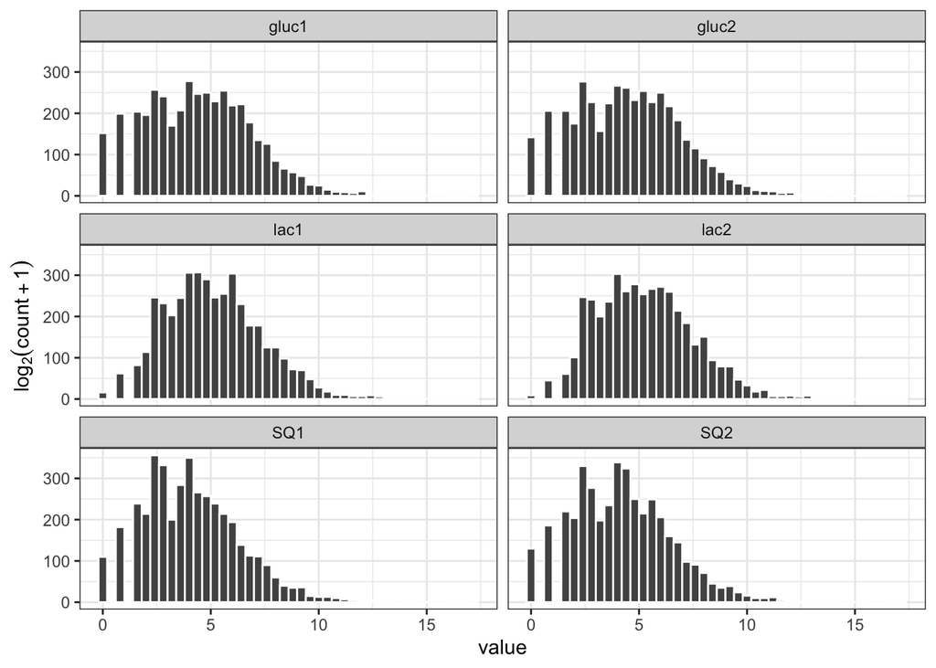

```r
raw_counts <- counts(dds) %>% as.data.frame(.)
pseudoCount = log2(raw_counts + 1)

as.data.frame(pseudoCount)%>%
pivot_longer(everything())%>%
ggplot(aes(value, fill=value)) +  ylab(expression(log[2](count + 1))) +
geom_histogram(colour = "white", fill = "#525252", binwidth = 0.4) +
scale_fill_manual(values = c('blue', 'red', 'burlywood')) +
facet_wrap(vars(name), nrow=3, ncol=2) + theme_bw()
```

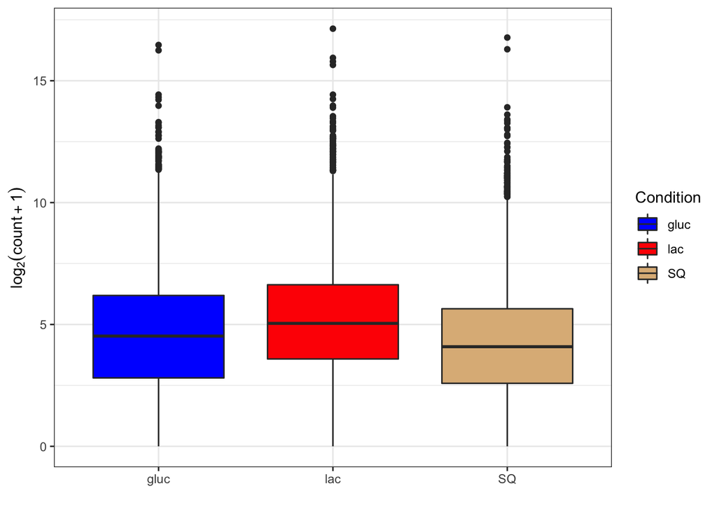

```r
df = melt(pseudoCount)
df = data.frame(df, Condition = gsub('.{1}$', '', df$variable))
ggplot(df, aes(x = Condition, y = value, fill = Condition)) +
  geom_boxplot() +
  xlab("") +
  ylab(expression(log[2](count + 1))) +
  scale_fill_manual(values = c('blue', 'red', 'burlywood')) +
  theme_bw()
```

#### Data quality assessment by sample clustering and visualization

##### PCA

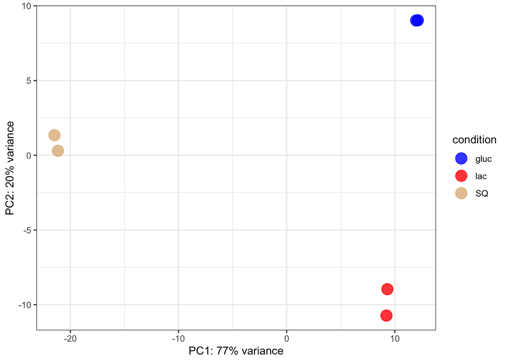

```r
### Transform counts for data visualization
rld <- rlog(dds, blind=TRUE)
### Plot PCA
pcaData <- plotPCA(rld, intgroup="condition" ,  returnData=TRUE)
percentVar <- round(100 * attr(pcaData, "percentVar"))
ggplot(pcaData, aes(PC1, PC2, color=condition)) +
  geom_point(size=5, aes(colour=condition), alpha = 0.8) +
  xlab(paste0("PC1: ",percentVar[1],"% variance")) +
  ylab(paste0("PC2: ",percentVar[2],"% variance")) +
scale_colour_manual(values = c('blue', 'red', 'burlywood')) +
theme_bw()
```

##### Hierarchical Clustering

```r
### Extract the rlog matrix from the object
rld_mat <- assay(rld)    ## assay() is function from the "SummarizedExperiment" package that was loaded when you loaded DESeq2

## Compute pairwise correlation values
rld_cor <- cor(rld_mat)    ## cor() is a base R function

head(rld_cor)   ## check the output of cor(), make note of the rownames and colnames
```

```
##             SQ1       SQ2     gluc1     gluc2      lac1      lac2
## SQ1   1.0000000 0.9914311 0.9566215 0.9574632 0.9599791 0.9613125
## SQ2   0.9914311 1.0000000 0.9572204 0.9579127 0.9587580 0.9609212
## gluc1 0.9566215 0.9572204 1.0000000 0.9944301 0.9795737 0.9827508
## gluc2 0.9574632 0.9579127 0.9944301 1.0000000 0.9801367 0.9837629
## lac1  0.9599791 0.9587580 0.9795737 0.9801367 1.0000000 0.9931486
## lac2  0.9613125 0.9609212 0.9827508 0.9837629 0.9931486 1.0000000
```

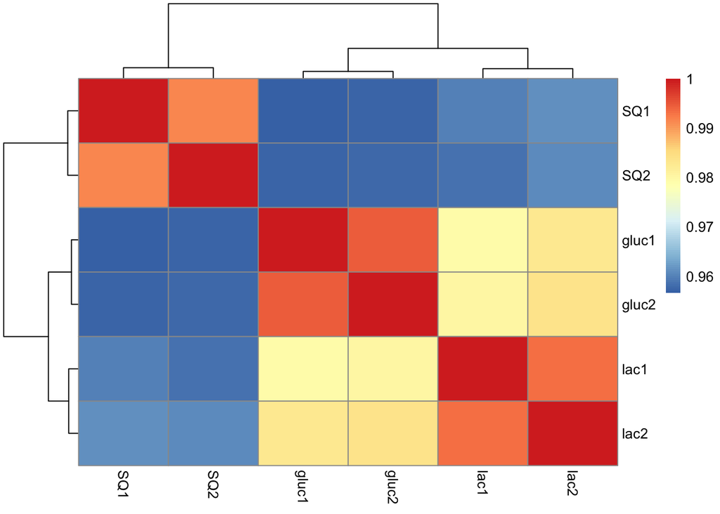

```r
### Plot heatmap
pheatmap(rld_cor)
```

### Get DESeq2 results

```r
dir.create(file.path(mainDir, 'DESeq_output'), showWarnings = FALSE)
setwd(file.path(mainDir, 'DESeq_output'))

sugars_to_compare <- c('SQ', 'lac')
for (sugar in sugars_to_compare){
    # Get results using contrasts
    message('...Getting results using contrasts...')
    assign(glue("res_{sugar}"), get_DESeq_results(dds, sugar_to_compare = sugar))
    # Write to file
    message(glue('...Writing to results to {strain}_{sugar}_vs_gluc_results_all.csv...'))
    write.table(as.data.frame(get(glue("res_{sugar}"))),
                file=file.path(mainDir, 'DESeq_output', glue('{strain}_{sugar}_vs_gluc_results_all.csv')),
                sep='\t', quote = F)
    message('Done')
    # Select Significant results based on padj
    message('...Selecting significant results based on padj...')
    assign(glue("resSig_{sugar}"), subset(get(glue("res_{sugar}")), padj < 0.05))
    # Write to file
    message(glue('...Writing to results to {strain}_{sugar}_vs_gluc_results_padj0.05.csv...'))
    write.table(as.data.frame(get(glue("resSig_{sugar}"))),
                file=file.path(mainDir, 'DESeq_output', glue('{strain}_{sugar}_vs_gluc_results_padj0.05.csv')),
                sep='\t', quote = F)
    message('Done')
}
```

### Volcano plots

```
## [1] "SQ"
```

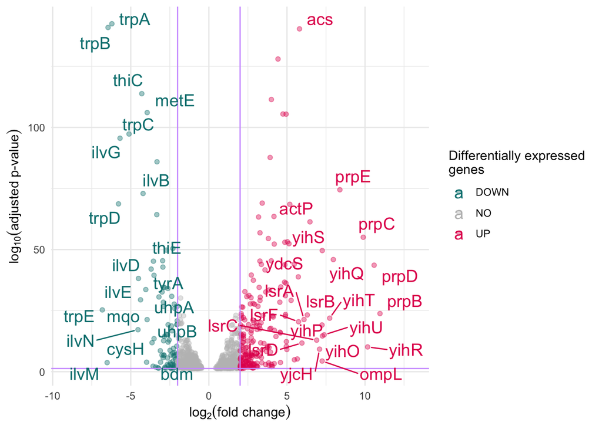

```
## [1] "lac"
```

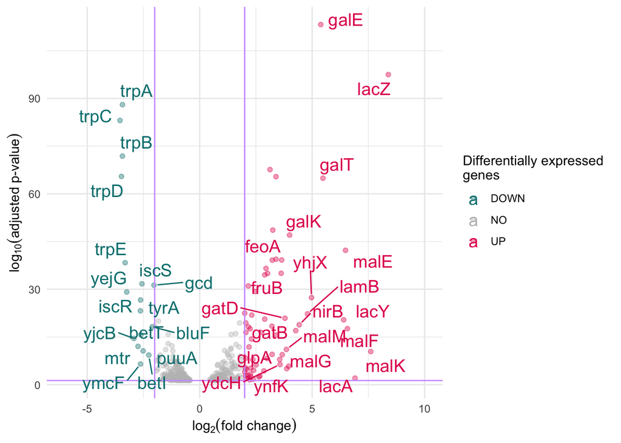

```r
sugars_to_compare <- c('SQ', 'lac')
for (sugar in sugars_to_compare){
    setwd(file.path(mainDir, 'DESeq_output'))
    png(glue("Volcano_{strain}_{sugar}_LFC2.png"),
        units="in", width=8, height=6, res=300)
    plot(plot_volcano(get(glue("resSig_{sugar}")),
                      l2fc_cutoff=2,
                      padj_cutoff=0.05,
                      top_number=20))

    dev.off()
    print(sugar)
    plot(plot_volcano(get(glue("resSig_{sugar}")),
                      l2fc_cutoff=2,
                      padj_cutoff=0.05,
                      top_number=20))
}
```

### Heatmaps

Plot heatmap of counts for 200 top variance genes filtering data with Log2FoldChange cutoff of 2 and 3:

```r
LFC_thresholdList <- c(2,3)
fontsize_rowList <- c(3,3)
top_var <- 200
eggnog_file <- glue('{strain}.emapper.annotations.tsv')

get_pheatmaps(LFC_thresholdList,
              fontsize_rowList,
              sugars_to_compare,
              top_var,
              eggnog_file_path=file.path(mainDir,eggnog_file),
              outputDir=file.path(mainDir, 'DESeq_output'),
              dds)
```

Plot heatmap of counts for 100 top variance genes filtering data with Log2FoldChange cutoff of 2 and 3:

```r
LFC_thresholdList <- c(2,3)
fontsize_rowList <- c(4,4)
top_var <- 100
eggnog_file <- glue('{strain}.emapper.annotations.tsv')

get_pheatmaps(LFC_thresholdList,
              fontsize_rowList,
              sugars_to_compare,
              top_var,
              eggnog_file_path=file.path(mainDir,eggnog_file),
              outputDir=file.path(mainDir, 'DESeq_output'),
              dds)
```

```r
LFC_thresholdList <- c(2,3)
fontsize_rowList <- c(12,12)
top_var <- 60
eggnog_file <- glue('{strain}.emapper.annotations.tsv')
get_pheatmaps(LFC_thresholdList,
              fontsize_rowList,
              sugars_to_compare,
              top_var,
              eggnog_file_path=file.path(mainDir,eggnog_file),
              outputDir=file.path(mainDir, 'DESeq_output'),
              dds, width_png=20, height_png=9)
```

Plot heatmap of counts for 40 top variance genes filtering data with Log2FoldChange cutoff of 2 and 3:

```r
LFC_thresholdList <- c(2,3)
fontsize_rowList <- c(12,12)
top_var <- 40
eggnog_file <- glue('{strain}.emapper.annotations.tsv')
get_pheatmaps(LFC_thresholdList,
              fontsize_rowList,
              sugars_to_compare,
              top_var,
              eggnog_file_path=file.path(mainDir,eggnog_file),
              outputDir=file.path(mainDir, 'DESeq_output'),
              dds, width_png=20, height_png=9)
```

## 3. Differential expression analysis for *E. coli* Nissle 1917

### Import data

```r
strain='Nissle'
mainDir <- '/Users/a1234/Documents/FCOM22/RNA_seq'

# Combine feature counts data and GFF annotation data
message('...Combining feature counts data and GFF annotation data...')
featureCounts_gff <- combine_featureCount_GFF_data(file.path(mainDir, glue('{strain}_merged')), file.path(mainDir, 'GCF_019967895.1_ASM1996789v1_genomic.gff'))

# Construct DESeqDataSet from count data
message('...Constructing DESeqDataSet from count data...')
dds <- construct_DESeqDataSet(featureCounts_gff)

# make the DeSeqDataSet
message('...Computing DESeq...')
dds <- compute_DESeq(dds)
```

### Quality control

#### Pseudo counts distribution

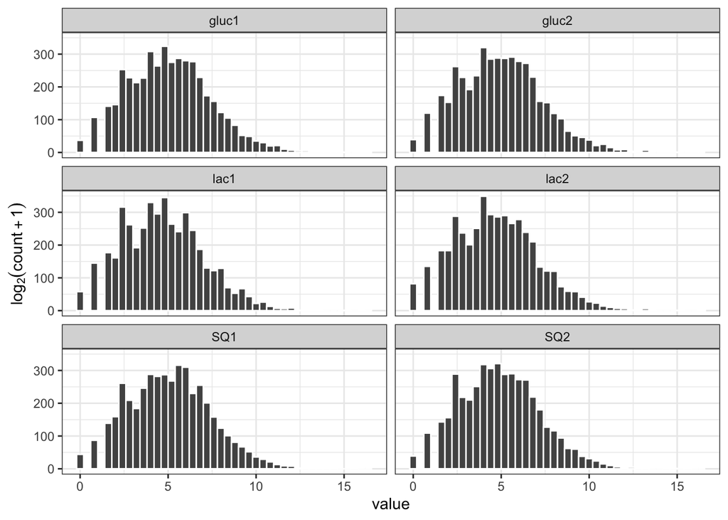

```r
raw_counts <- counts(dds) %>% as.data.frame(.)
pseudoCount = log2(raw_counts + 1)

as.data.frame(pseudoCount)%>%
pivot_longer(everything())%>%
ggplot(aes(value, fill=value)) +  ylab(expression(log[2](count + 1))) +
geom_histogram(colour = "white", fill = "#525252", binwidth = 0.4) +
scale_fill_manual(values = c('blue', 'red', 'burlywood')) +
facet_wrap(vars(name), nrow=3, ncol=2) + theme_bw()
```

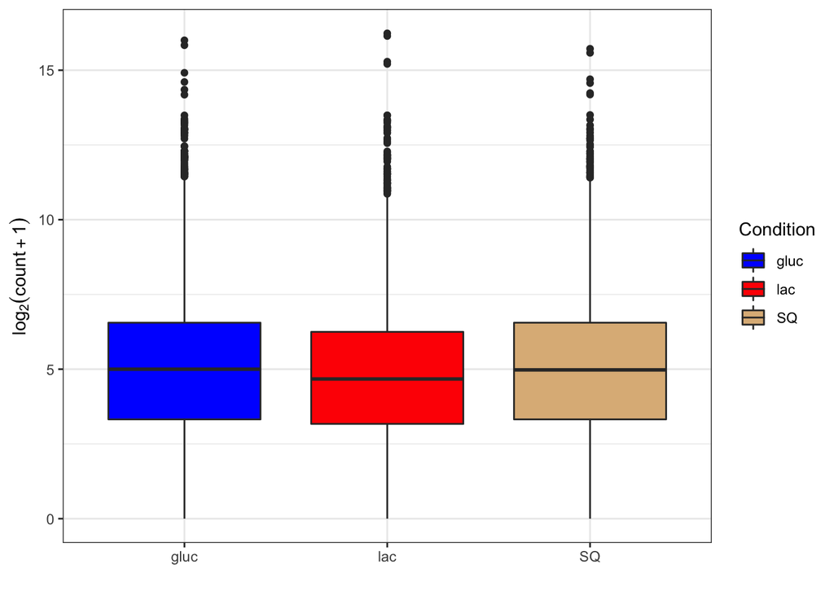

```r
df = melt(pseudoCount)
df = data.frame(df, Condition = gsub('.{1}$', '', df$variable))
ggplot(df, aes(x = Condition, y = value, fill = Condition)) +
  geom_boxplot() +
  xlab("") +
  ylab(expression(log[2](count + 1))) +
  scale_fill_manual(values = c('blue', 'red', 'burlywood')) +
  theme_bw()
```

#### Data quality assessment by sample clustering and visualization

##### PCA

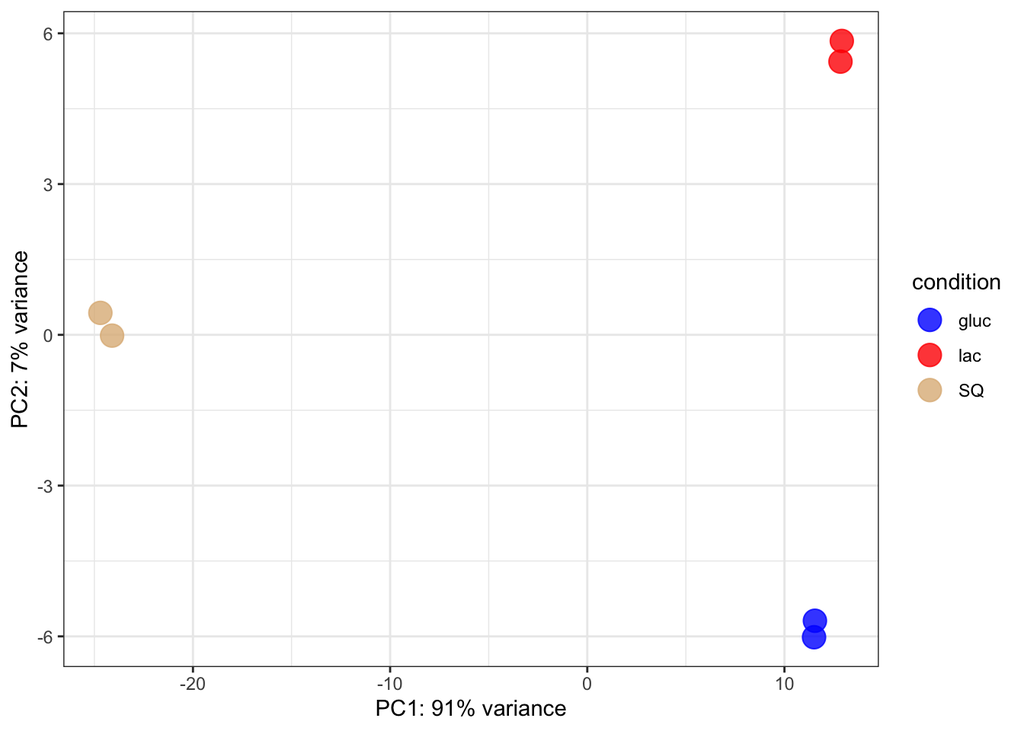

```r
### Transform counts for data visualization
rld <- rlog(dds, blind=TRUE)
### Plot PCA
pcaData <- plotPCA(rld, intgroup="condition" ,  returnData=TRUE)
percentVar <- round(100 * attr(pcaData, "percentVar"))
ggplot(pcaData, aes(PC1, PC2, color=condition)) +
  geom_point(size=5, aes(colour=condition), alpha = 0.8) +
  xlab(paste0("PC1: ",percentVar[1],"% variance")) +
  ylab(paste0("PC2: ",percentVar[2],"% variance")) +
scale_colour_manual(values = c('blue', 'red', 'burlywood')) +
theme_bw()
```

##### Hierarchical Clustering

```r
### Extract the rlog matrix from the object
rld_mat <- assay(rld)    ## assay() is function from the "SummarizedExperiment" package that was loaded when you loaded DESeq2

## Compute pairwise correlation values
rld_cor <- cor(rld_mat)    ## cor() is a base R function

head(rld_cor)   ## check the output of cor(), make note of the rownames and colnames
```

```
##             SQ1       SQ2     gluc1     gluc2      lac1      lac2
## SQ1   1.0000000 0.9931496 0.9570329 0.9577517 0.9533785 0.9528766
## SQ2   0.9931496 1.0000000 0.9572515 0.9583483 0.9534835 0.9530006
## gluc1 0.9570329 0.9572515 1.0000000 0.9943745 0.9893534 0.9881035
## gluc2 0.9577517 0.9583483 0.9943745 1.0000000 0.9899153 0.9891822
## lac1  0.9533785 0.9534835 0.9893534 0.9899153 1.0000000 0.9934950
## lac2  0.9528766 0.9530006 0.9881035 0.9891822 0.9934950 1.0000000
```

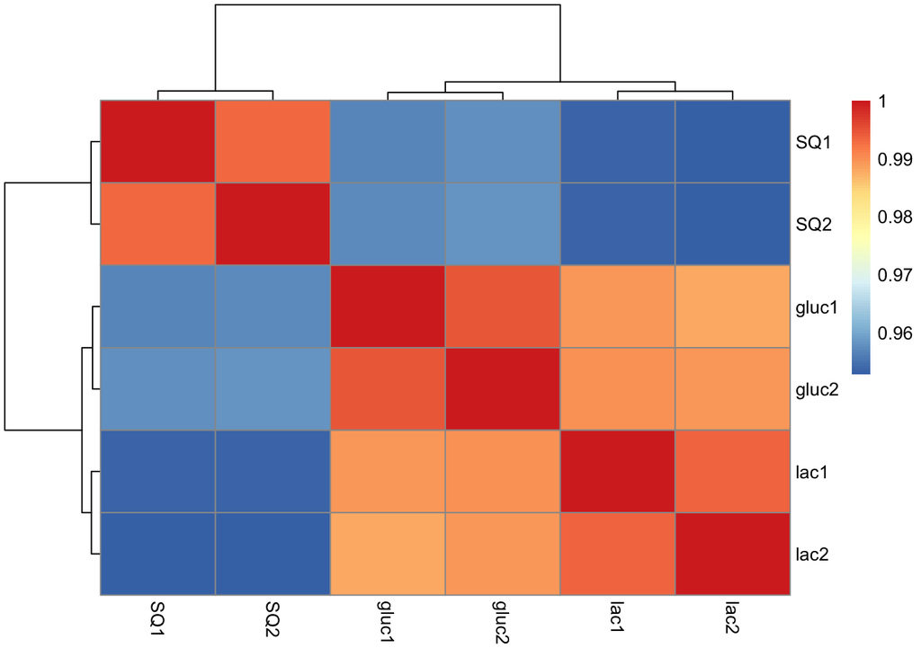

```r
### Plot heatmap
pheatmap(rld_cor)
```

### Get DESeq2 results

```r
dir.create(file.path(mainDir, 'DESeq_output'), showWarnings = FALSE)
setwd(file.path(mainDir, 'DESeq_output'))

sugars_to_compare <- c('SQ', 'lac')
for (sugar in sugars_to_compare){
    # Get results using contrasts
    message('...Getting results using contrasts...')
    assign(glue("res_{sugar}"), get_DESeq_results(dds, sugar_to_compare = sugar))
    # Write to file
    message(glue('...Writing to results to {strain}_{sugar}_vs_gluc_results_all.csv...'))
    write.table(as.data.frame(get(glue("res_{sugar}"))),
                file=file.path(mainDir, 'DESeq_output', glue('{strain}_{sugar}_vs_gluc_results_all.csv')),
                sep='\t', quote = F)
    message('Done')
    # Select Significant results based on padj
    message('...Selecting significant results based on padj...')
    assign(glue("resSig_{sugar}"), subset(get(glue("res_{sugar}")), padj < 0.05))
    # Write to file
    message(glue('...Writing to results to {strain}_{sugar}_vs_gluc_results_padj0.05.csv...'))
    write.table(as.data.frame(get(glue("resSig_{sugar}"))),
                file=file.path(mainDir, 'DESeq_output', glue('{strain}_{sugar}_vs_gluc_results_padj0.05.csv')),
                sep='\t', quote = F)
    message('Done')
}
```

### Volcano plots

Cutoff value for log2FoldChange = 2

```r
sugars_to_compare <- c('SQ', 'lac')
for (sugar in sugars_to_compare){
    setwd(file.path(mainDir, 'DESeq_output'))
    png(glue("Volcano_{strain}_{sugar}_LFC2.png"),
        units="in", width=8, height=6, res=300)
    plot(plot_volcano(get(glue("resSig_{sugar}")),
                      l2fc_cutoff=2,
                      padj_cutoff=0.05,
                      top_number=20))

    dev.off()
    #print(sugar)
    plot(plot_volcano(get(glue("resSig_{sugar}")),
                      l2fc_cutoff=2,
                      padj_cutoff=0.05,
                      top_number=20))
}
```

[output not shown]

Cutoff value for log2FoldChange = 1.32

```
## [1] "SQ"
```

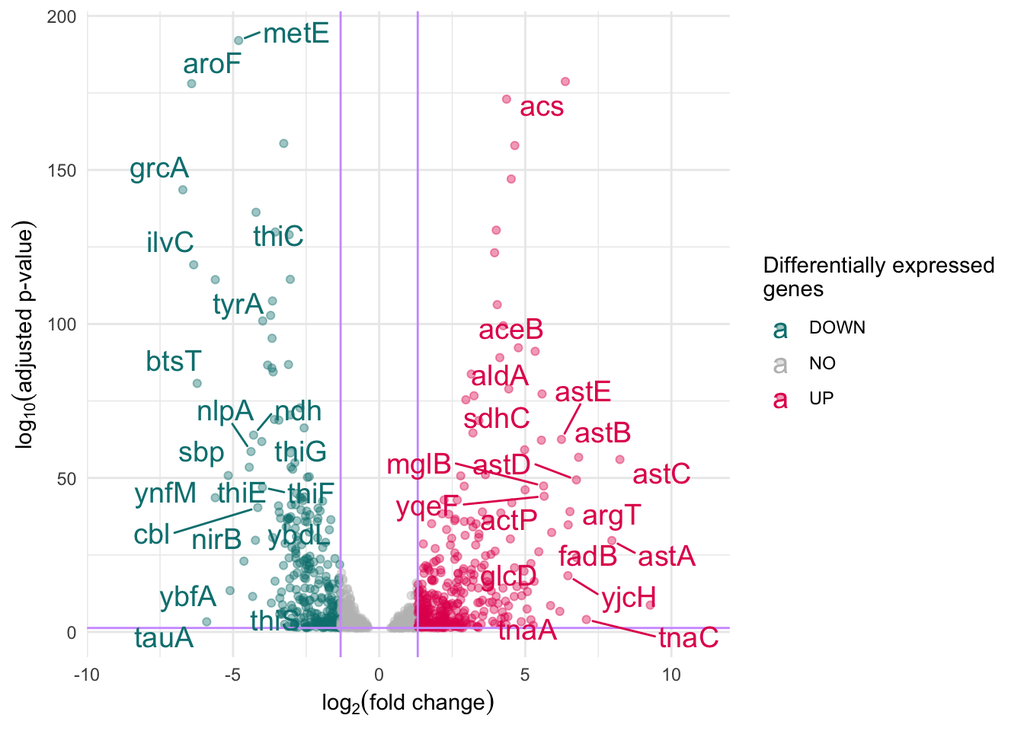

```
## [1] "lac"
```

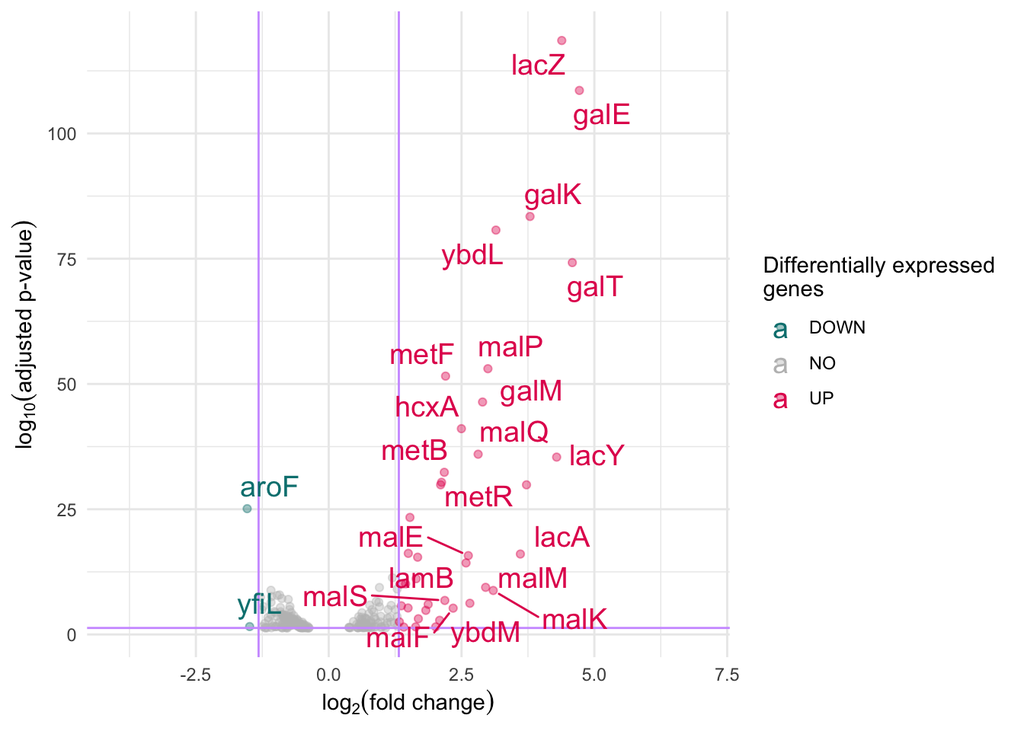

```r
sugars_to_compare <- c('SQ', 'lac')
for (sugar in sugars_to_compare){
    setwd(file.path(mainDir, 'DESeq_output'))
    png(glue("Volcano_{strain}_{sugar}_LFC2.png"),
        units="in", width=8, height=6, res=300)
    plot(plot_volcano(get(glue("resSig_{sugar}")),
                      l2fc_cutoff=1.32,
                      padj_cutoff=0.05,
                      top_number=20))

    dev.off()
    print(sugar)
    plot(plot_volcano(get(glue("resSig_{sugar}")),
                      l2fc_cutoff=1.32,
                      padj_cutoff=0.05,
                      top_number=20))
}
```

### Heatmaps

Plot heatmap of counts for 100 top variance genes filtering data with Log2FoldChange cutoff of 2 and 3:

```r
LFC_thresholdList <- c(2,3)
fontsize_rowList <- c(4,4)
top_var <- 100
eggnog_file <- glue('{strain}.emapper.annotations.tsv')

get_pheatmaps(LFC_thresholdList,
              fontsize_rowList,
              sugars_to_compare,
              top_var,
              eggnog_file_path=file.path(mainDir,eggnog_file),
              outputDir=file.path(mainDir, 'DESeq_output'),
              dds, width_png=10, height_png=9)
```

Plot heatmap of counts for 200 top variance genes filtering data with Log2FoldChange cutoff of 2 and 3:

```r
LFC_thresholdList <- c(2,3)
fontsize_rowList <- c(3,3)
top_var <- 200
eggnog_file <- glue('{strain}.emapper.annotations.tsv')

get_pheatmaps(LFC_thresholdList,
              fontsize_rowList,
              sugars_to_compare,
              top_var,
              eggnog_file_path=file.path(mainDir,eggnog_file),
              outputDir=file.path(mainDir, 'DESeq_output'),
              dds, width_png=10, height_png=9)
```

Plot heatmap of counts for 50 top variance genes filtering data with Log2FoldChange cutoff of 2 and 3:

```r
LFC_thresholdList <- c(2,3)
fontsize_rowList <- c(12,12)
top_var <- 50
eggnog_file <- glue('{strain}.emapper.annotations.tsv')

get_pheatmaps(LFC_thresholdList,
              fontsize_rowList,
              sugars_to_compare,
              top_var,
              eggnog_file_path=file.path(mainDir,eggnog_file),
              outputDir=file.path(mainDir, 'DESeq_output'),
              dds, width_png=20, height_png=9)
```

Plot heatmap of counts for 40 top variance genes filtering data with Log2FoldChange cutoff of 2 and 3:

```r
LFC_thresholdList <- c(2,3)
fontsize_rowList <- c(12,12)
top_var <- 40
eggnog_file <- glue('{strain}.emapper.annotations.tsv')

get_pheatmaps(LFC_thresholdList,
              fontsize_rowList,
              sugars_to_compare,
              top_var,
              eggnog_file_path=file.path(mainDir,eggnog_file),
              outputDir=file.path(mainDir, 'DESeq_output'),
              dds, width_png=20, height_png=9)
```